# Tuesday Exercises

## Question 1

### (a)

```r
setwd(dirname(rstudioapi::getActiveDocumentContext()$path))
calcium_data <- read.table(file="T3_3_Calcium.DAT", sep="")
calcium_data
```

```
##    V1 V2   V3   V4
## 1   1 35  3.5 2.80
## 2   2 35  4.9 2.70
## 3   3 40 30.0 4.38
## 4   4 10  2.8 3.21
## 5   5  6  2.7 2.73
## 6   6 20  2.8 2.81
## 7   7 35  4.6 2.88
## 8   8 35 10.9 2.90
## 9   9 35  8.0 3.28
## 10 10 30  1.6 3.20
```

```r
names(calcium_data) <- c("location","avail","exch","turnip-green-calc")
calcium_data
```

```
##    location avail exch turnip-green-calc
## 1         1    35  3.5              2.80
## 2         2    35  4.9              2.70
## 3         3    40 30.0              4.38
## 4         4    10  2.8              3.21
## 5         5     6  2.7              2.73
## 6         6    20  2.8              2.81
## 7         7    35  4.6              2.88
## 8         8    35 10.9              2.90
## 9         9    35  8.0              3.28
## 10       10    30  1.6              3.20
```

### (b)

```r
cov_mat <- cov(calcium_data[,2:4])
cov_mat
```

```
##                        avail      exch turnip-green-calc
## avail             140.544444 49.680000         1.9412222
## exch               49.680000 72.248444         3.6760889
## turnip-green-calc   1.941222  3.676089         0.2501211
```

```r
cor_mat <- cor(calcium_data[,2:4])
cor_mat
```

```
##                       avail      exch turnip-green-calc
## avail             1.0000000 0.4930154          0.327411
## exch              0.4930154 1.0000000          0.864762
## turnip-green-calc 0.3274110 0.8647620          1.000000
```

```r
mean_vec <- colMeans(calcium_data[,2:4])
mean_vec
```

```
##             avail              exch turnip-green-calc
##            28.100             7.180             3.089
```

- Variance of the turnip green calcium level is 0.25. Standard deviation of it is 0.5. Covariance between available and exchangeable is 49.68.
- They have a linear positive association but not sure due its magnitude being tough to interpret. A better comparison would be the correlation coefficient in the correlation matrix where the value is 0.49. This shows that there is a moderate linear positive association.
- More strongly associated with exchangeable with a value of 0.86.

### (c)

Make a scatterplot matrix of the 3 variables.

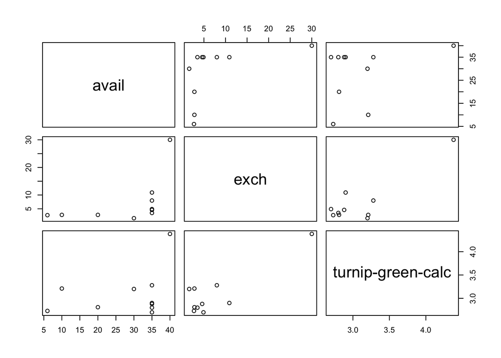

```r
pairs(calcium_data[,2:4])
```

From this it would seem that between avail and exch there is somewhat weak positive linear association. Between exch and turnip green levels there is a better trend. And with turnip green and avail there is also a weak association between the variables.

### (d)

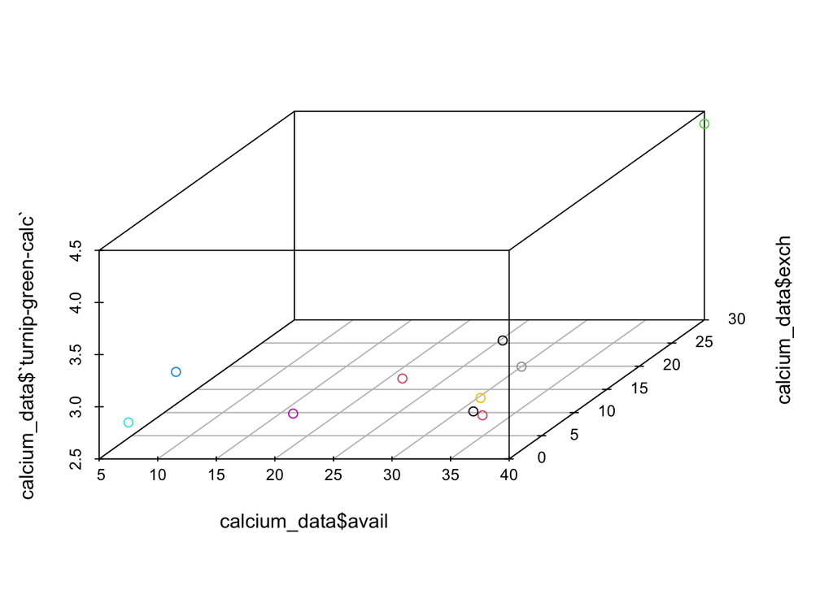

```r
# scatterplot3d function requires scatterplot3d library. Also add color to the points by what data point they are/
library(scatterplot3d)
scatterplot3d(x=calcium_data$avail, y=calcium_data$exch, z=calcium_data$`turnip-green-calc`, color=calcium_data$location)
```

From this 3D graph, its is somewhat hard to tell what patterns exist in the data since they are not grouped by anything meaningful other than location.

### (e)

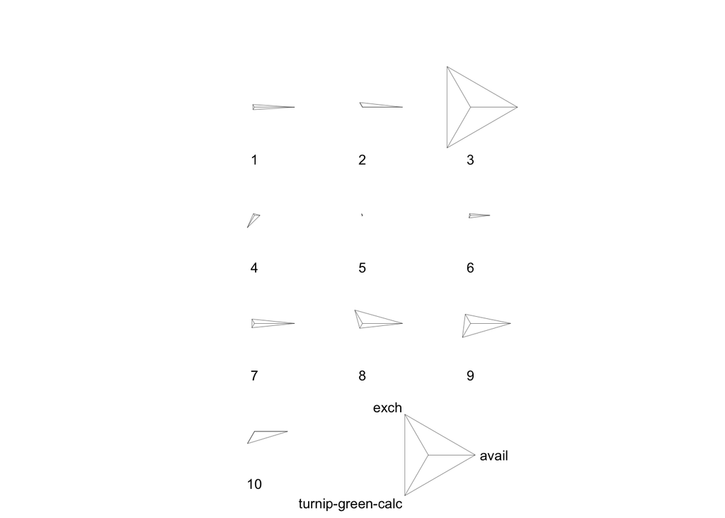

```r
stars(calcium_data[,2:4], labels=calcium_data$location, key.loc=c(6, 1.8))
```

- Location 3 has massive values for all 3 variables: exch, turnip green and avail calcium levels
- Locations seem to have a lot of avail calcium levels.

## Question 2

### (a)

```r
setwd(dirname(rstudioapi::getActiveDocumentContext()$path))
probes <- read.table(file="T3_5_Probe.DAT", sep="")
probes
```

```
##    V1 V2 V3 V4 V5 V6
## 1   1 51 36 50 35 42
## 2   2 27 20 26 17 27
## 3   3 37 22 41 37 30
## 4   4 42 36 32 34 27
## 5   5 27 18 33 14 29
## 6   6 43 32 43 35 40
## 7   7 41 22 36 25 38
## 8   8 38 21 31 20 16
## 9   9 36 23 27 25 28
## 10 10 26 31 31 32 36
## 11 11 29 20 25 26 25
```

```r
names(probes) <- c("subject_no","y1","y2","y3","y4","y5")
probes
```

```
##    subject_no y1 y2 y3 y4 y5
## 1           1 51 36 50 35 42
## 2           2 27 20 26 17 27
## 3           3 37 22 41 37 30
## 4           4 42 36 32 34 27
## 5           5 27 18 33 14 29
## 6           6 43 32 43 35 40
## 7           7 41 22 36 25 38
## 8           8 38 21 31 20 16
## 9           9 36 23 27 25 28
## 10         10 26 31 31 32 36
## 11         11 29 20 25 26 25
```

### (b)

Create a parallel coordinates plot of the 5 response times for the 11 subjects.

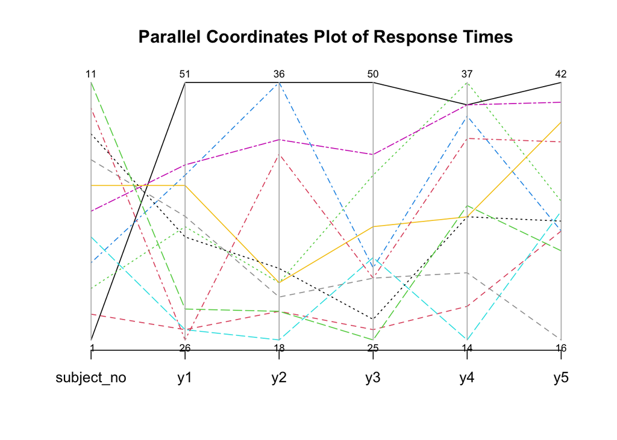

```r
library(MASS)
parcoord(probes, col=1:11, lty=1:11, main="Parallel Coordinates Plot of Response Times", var.label=TRUE)
```

There does not seem to be any groupings in the data, which means it looks like it is a random jumble of responses for each of the subjects.

### (c)

```r
age <- c(rep(1, 5), rep(2, 6))
```

Generate a parallel coordinates plot where younger adults are in red and older adults are in blue.

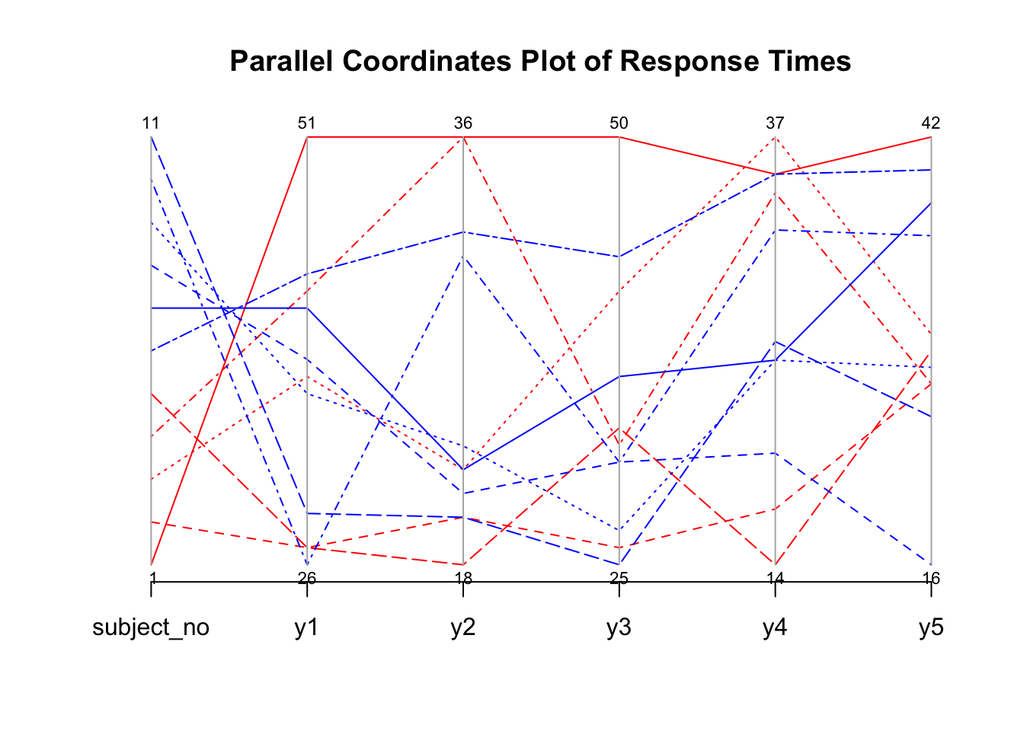

```r
colors <- c("Red", "Blue")
parcoord(probes, col=colors[age], lty=1:11, main="Parallel Coordinates Plot of Response Times", var.label=TRUE)
```